# Distribuciones y Correlaciones

1 Distribución de temperaturas

2 Distribución de precipitaciones

3 Distribución de variables de calidad del aire

4 Distribución del porcentaje de ocupación

5 Correlaciones entre las covariantes y el target

6 Correlación entre las covariantes (entre sí)

```python
import pandas as pd
import numpy as np
import matplotlib.pyplot as plt
import seaborn as sns
%matplotlib inline
```

```python
df = pd.read_csv('./data/Serie_Total2016_ext.csv', parse_dates=['timestamp'])
df.head(10)
```

|  | element_key | latitude | longitude | timestamp | paid_parking_area | day_year | occupation_perc | prcp | tmax | tmin | ... | poi | baseball | tennis | basket | soccer | event | no2 | co | pm2_5 | o3 |
| --- | --- | --- | --- | --- | --- | --- | --- | --- | --- | --- | --- | --- | --- | --- | --- | --- | --- | --- | --- | --- | --- |
| 0 | 1001 | 47.602862 | -122.334703 | 2016-01-02 08:00:00 | Pioneer Square | 2 | 0.00 | 0.0 | 5.56 | -3.89 | ... | 1 | 0 | 0 | 0 | 0 | 0 | 71.001333 | 1030.5 | 19.875 | 83.0 |
| 1 | 1001 | 47.602862 | -122.334703 | 2016-01-02 09:00:00 | Pioneer Square | 2 | 0.00 | 0.0 | 5.56 | -3.89 | ... | 1 | 0 | 0 | 0 | 0 | 0 | 71.001333 | 1030.5 | 19.875 | 83.0 |
| 2 | 1001 | 47.602862 | -122.334703 | 2016-01-02 10:00:00 | Pioneer Square | 2 | 0.00 | 0.0 | 5.56 | -3.89 | ... | 1 | 0 | 0 | 0 | 0 | 0 | 71.001333 | 1030.5 | 19.875 | 83.0 |
| 3 | 1001 | 47.602862 | -122.334703 | 2016-01-02 11:00:00 | Pioneer Square | 2 | 0.00 | 0.0 | 5.56 | -3.89 | ... | 1 | 0 | 0 | 0 | 0 | 0 | 71.001333 | 1030.5 | 19.875 | 83.0 |
| 4 | 1001 | 47.602862 | -122.334703 | 2016-01-02 12:00:00 | Pioneer Square | 2 | 0.00 | 0.0 | 5.56 | -3.89 | ... | 1 | 0 | 0 | 0 | 0 | 0 | 71.001333 | 1030.5 | 19.875 | 83.0 |
| 5 | 1001 | 47.602862 | -122.334703 | 2016-01-02 13:00:00 | Pioneer Square | 2 | 7.14 | 0.0 | 5.56 | -3.89 | ... | 1 | 0 | 0 | 0 | 0 | 0 | 71.001333 | 1030.5 | 19.875 | 83.0 |
| 6 | 1001 | 47.602862 | -122.334703 | 2016-01-02 14:00:00 | Pioneer Square | 2 | 7.14 | 0.0 | 5.56 | -3.89 | ... | 1 | 0 | 0 | 0 | 0 | 0 | 71.001333 | 1030.5 | 19.875 | 83.0 |
| 7 | 1001 | 47.602862 | -122.334703 | 2016-01-02 15:00:00 | Pioneer Square | 2 | 0.00 | 0.0 | 5.56 | -3.89 | ... | 1 | 0 | 0 | 0 | 0 | 0 | 71.001333 | 1030.5 | 19.875 | 83.0 |
| 8 | 1001 | 47.602862 | -122.334703 | 2016-01-02 16:00:00 | Pioneer Square | 2 | 0.00 | 0.0 | 5.56 | -3.89 | ... | 1 | 0 | 0 | 0 | 0 | 0 | 71.001333 | 1030.5 | 19.875 | 83.0 |
| 9 | 1001 | 47.602862 | -122.334703 | 2016-01-02 17:00:00 | Pioneer Square | 2 | 0.00 | 0.0 | 5.56 | -3.89 | ... | 1 | 0 | 0 | 0 | 0 | 0 | 71.001333 | 1030.5 | 19.875 | 83.0 |

10 rows × 22 columns

```python
df.shape[0]
```

```
3851664
```

```python
# Funciones estadísticas
from scipy.stats import norm, t, beta, expon, gamma
```

# Distribución de temperaturas

### Temperatura máxima

```python
mu = df['tmax'].mean()
s = df['tmax'].std()
print("Temperatura máxima media de la muestra: %.2fºC" % mu)
print("Desviación típica de la Temperatura máxima de la muestra: %.2fºC" % s)
```

```
Temperatura máxima media de la muestra: 17.14ºC
Desviación típica de la Temperatura máxima de la muestra: 7.06ºC
```

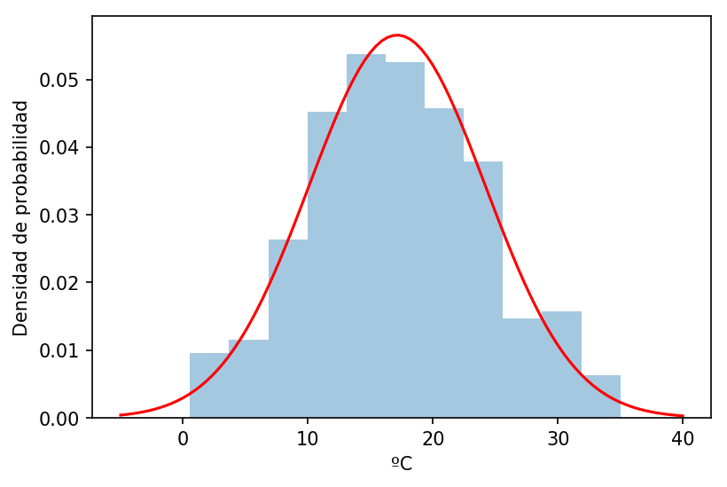

```python
plt.figure(dpi=150)
sns.distplot(df['tmax'], bins=11, kde=False, norm_hist=True)
x = np.linspace(-5,40, 100)
rv = norm(loc=mu, scale=s)
plt.plot(x, rv.pdf(x), color='r')
plt.xlabel("ºC")
plt.ylabel("Densidad de probabilidad");
```

Muestra grande, varianza poblacional desconocida

$ \Big(\bar{x}-z_{\alpha/2}\cdot\dfrac{s}{\sqrt{N}}, \;\bar{x}+z_{\alpha/2}\cdot\dfrac{s}{\sqrt{N}}\Big), \; 1-\alpha $

```python
def confint_mean_normal(x, s, N, alpha):
    from scipy.stats import norm
    import numpy as np
    import pandas as pd

    rv = norm()
    za = np.abs(rv.ppf(alpha/2))
    mu_i = x-za*s/np.sqrt(N)
    mu_s = x+za*s/np.sqrt(N)
    return pd.DataFrame({str(100*(alpha/2))+"%": [mu_i], str(100*(1-alpha/2))+"%": [mu_s]})
```

Muestra grande, media poblacional desconocida

$ \Big(\dfrac{Ns^2}{\chi^2_{\alpha/2}}, \dfrac{Ns^2}{\chi^2_{1-\alpha/2}} \Big), \; 1-\alpha $

```python
def confint_variance(s, N, alpha):
    from scipy.stats import chi2
    import numpy as np
    import pandas as pd

    rv = chi2(N)
    x1 = rv.ppf(alpha/2)
    x2 = rv.ppf(1-alpha/2)
    s_i = np.sqrt(N*s**2/max(x1,x2))
    s_s = np.sqrt(N*s**2/min(x1,x2))

    return pd.DataFrame({str(100*(alpha/2))+"%": [s_i], str(100*(1-alpha/2))+"%": [s_s]})
```

```python
confint_mean_normal(mu, s, df.shape[0], 0.05)
```

|  | 2.5% | 97.5% |
| --- | --- | --- |
| 0 | 17.136426 | 17.150518 |

```python
confint_variance(s, df.shape[0], 0.05)
```

|  | 2.5% | 97.5% |
| --- | --- | --- |
| 0 | 7.050589 | 7.060554 |

### Temperatura mínima

```python
mu = df['tmin'].mean()
s = df['tmin'].std()
print("Temperatura mínima media de la muestra: %.2fºC" % mu)
print("Desviación típica de la Temperatura mínima de la muestra: %.2fºC" % s)
```

```
Temperatura mínima media de la muestra: 8.74ºC
Desviación típica de la Temperatura mínima de la muestra: 4.54ºC
```

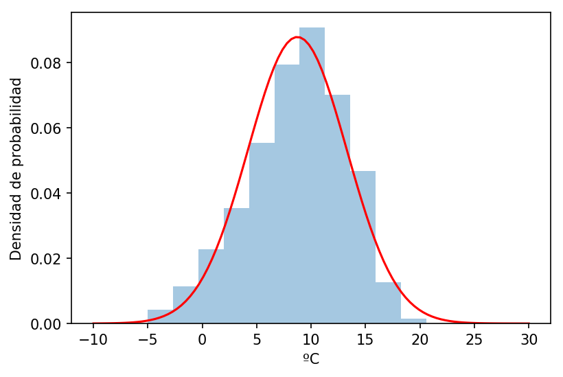

```python
plt.figure(dpi=150)
sns.distplot(df['tmin'], bins=11, kde=False, norm_hist=True)
x = np.linspace(-10, 30, 100)
rv = norm(loc=mu, scale=s)
plt.plot(x, rv.pdf(x), color='r')
plt.xlabel("ºC")
plt.ylabel("Densidad de probabilidad");
```

```python
confint_mean_normal(mu, s, df.shape[0], 0.05)
```

|  | 2.5% | 97.5% |
| --- | --- | --- |
| 0 | 8.73151 | 8.740577 |

```python
confint_variance(s, df.shape[0], 0.05)
```

|  | 2.5% | 97.5% |
| --- | --- | --- |
| 0 | 4.536045 | 4.542456 |

### Temperatura media horaria del asfalto

```python
mu = df['road_temp'].mean()
s = df['road_temp'].std()
print("Temperatura media del asfalto de la muestra: %.2fºC" % mu)
print("Desviación típica de la Temperatura media del asfalto de la muestra: %.2fºC" % s)
```

```
Temperatura media del asfalto de la muestra: 18.28ºC
Desviación típica de la Temperatura media del asfalto de la muestra: 9.16ºC
```

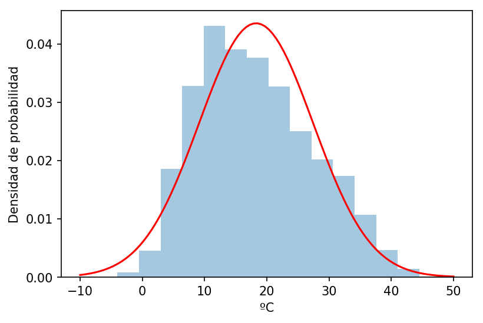

```python
plt.figure(dpi=150)
sns.distplot(df['road_temp'], bins=15, kde=False, norm_hist=True)
x = np.linspace(-10,50, 100)
rv = norm(loc=mu, scale=s)
plt.plot(x, rv.pdf(x), color='r')
plt.xlabel("ºC")
plt.ylabel("Densidad de probabilidad");
```

```python
confint_mean_normal(mu, s, df.shape[0], 0.05)
```

|  | 2.5% | 97.5% |
| --- | --- | --- |
| 0 | 18.265901 | 18.284199 |

```python
confint_variance(s, df.shape[0], 0.05)
```

|  | 2.5% | 97.5% |
| --- | --- | --- |
| 0 | 9.154978 | 9.167917 |

### Temperatura media horaria ambiente

```python
mu = df['air_temp'].mean()
s = df['air_temp'].std()
print("Temperatura media ambiente de la muestra: %.2fºC" % mu)
print("Desviación típica de la Temperatura media ambiente de la muestra: %.2fºC" % s)
```

```
Temperatura media ambiente de la muestra: 14.65ºC
Desviación típica de la Temperatura media ambiente de la muestra: 6.39ºC
```

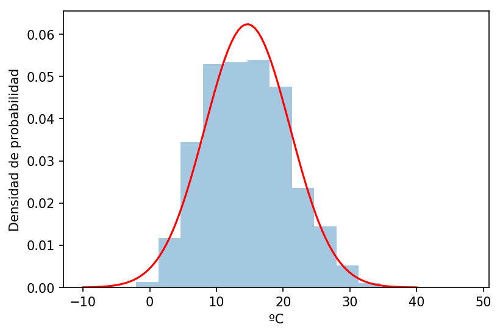

```python
plt.figure(dpi=150)
sns.distplot(df['air_temp'], bins=15, kde=False, norm_hist=True)
x = np.linspace(-10,40, 100)
rv = norm(loc=mu, scale=s)
plt.plot(x, rv.pdf(x), color='r')
plt.xlabel("ºC")
plt.ylabel("Densidad de probabilidad");
```

```python
confint_mean_normal(mu, s, df.shape[0], 0.05)
```

|  | 2.5% | 97.5% |
| --- | --- | --- |
| 0 | 14.646286 | 14.659056 |

```python
confint_variance(s, df.shape[0], 0.05)
```

|  | 2.5% | 97.5% |
| --- | --- | --- |
| 0 | 6.389159 | 6.398189 |

# Distribución de precipitaciones

```python
mu = df['prcp'].mean()
s = df['prcp'].std()
print("Precipitación media de la muestra: %.2f" % mu)
print("Desviación típica de la precipitación de la muestra: %.2f" % s)
```

```
Precipitación media de la muestra: 0.13
Desviación típica de la precipitación de la muestra: 0.26
```

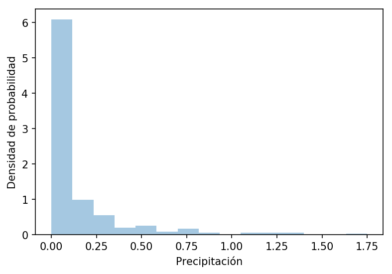

```python
import math
plt.figure(dpi=150)
sns.distplot(df['prcp'], bins=15, kde=False, norm_hist=True)
plt.xlabel("Precipitación")
plt.ylabel("Densidad de probabilidad");
```

```python
confint_mean_normal(mu, s, df.shape[0], 0.05)
```

|  | 2.5% | 97.5% |
| --- | --- | --- |
| 0 | 0.127334 | 0.127845 |

```python
confint_variance(s, df.shape[0], 0.05)
```

|  | 2.5% | 97.5% |
| --- | --- | --- |
| 0 | 0.255754 | 0.256115 |

# Distribución de variables de calidad del aire

### CO

```python
mu = df['co'].mean()
s = df['co'].std()
print("Cantidad de CO media de la muestra: %.2f" % mu)
print("Desviación típica de la medida de CO de la muestra: %.2f" % s)
```

```
Cantidad de CO media de la muestra: 512.55
Desviación típica de la medida de CO de la muestra: 194.61
```

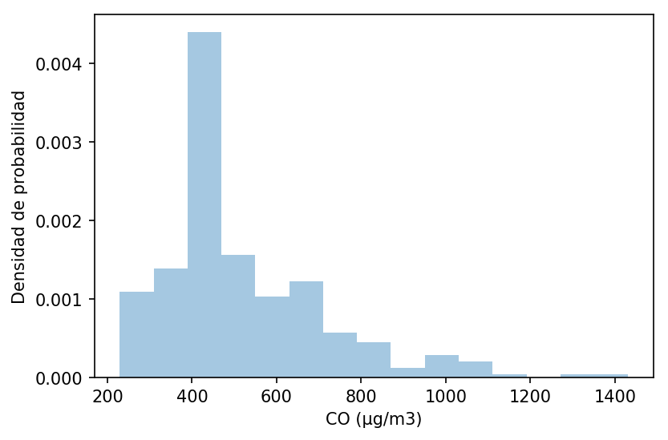

```python
plt.figure(dpi=150)
sns.distplot(df['co'], bins=15, kde=False, norm_hist=True)
plt.xlabel("CO (µg/m3)")
plt.ylabel("Densidad de probabilidad");
```

```python
confint_mean_normal(mu, s, df.shape[0], 0.05)
```

|  | 2.5% | 97.5% |
| --- | --- | --- |
| 0 | 512.354853 | 512.743557 |

```python
confint_variance(s, df.shape[0], 0.05)
```

|  | 2.5% | 97.5% |
| --- | --- | --- |
| 0 | 194.472437 | 194.747292 |

### NO<sub>2</sub>

```python
mu = df['no2'].mean()
s = df['no2'].std()
print("Cantidad de NO2 media de la muestra: %.2f" % mu)
print("Desviación típica de la medida de NO2 de la muestra: %.2f" % s)
```

```
Cantidad de NO2 media de la muestra: 56.65
Desviación típica de la medida de NO2 de la muestra: 14.79
```

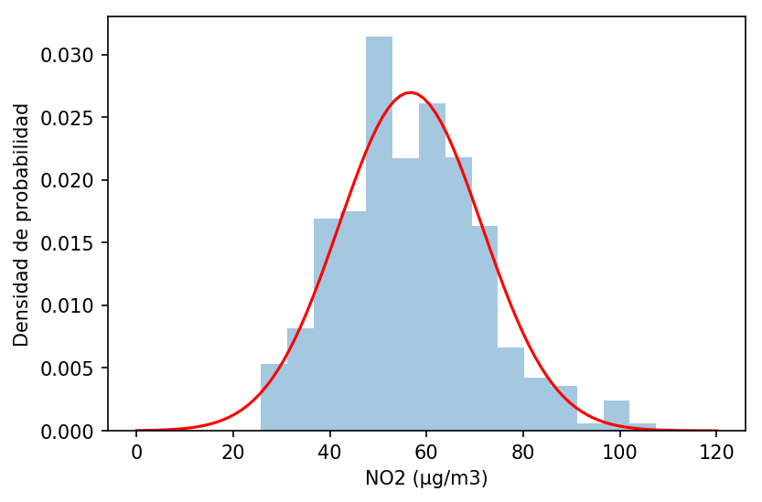

```python
plt.figure(dpi=150)
sns.distplot(df['no2'], bins=15, kde=False, norm_hist=True)
x = np.linspace(0, 120, 100)
rv = norm(loc=mu, scale=s)
plt.plot(x, rv.pdf(x), color='r')
plt.xlabel("NO2 (µg/m3)")
plt.ylabel("Densidad de probabilidad");
```

```python
confint_mean_normal(mu, s, df.shape[0], 0.05)
```

|  | 2.5% | 97.5% |
| --- | --- | --- |
| 0 | 56.633874 | 56.663414 |

```python
confint_variance(s, df.shape[0], 0.05)
```

|  | 2.5% | 97.5% |
| --- | --- | --- |
| 0 | 14.779377 | 14.800265 |

### O<sub>3</sub>

```python
mu = df['o3'].mean()
s = df['o3'].std()
print("Cantidad de O3 media de la muestra: %.2f" % mu)
print("Desviación típica de la medida de O3 de la muestra: %.2f" % s)
```

```
Cantidad de O3 media de la muestra: 67.16
Desviación típica de la medida de O3 de la muestra: 16.31
```

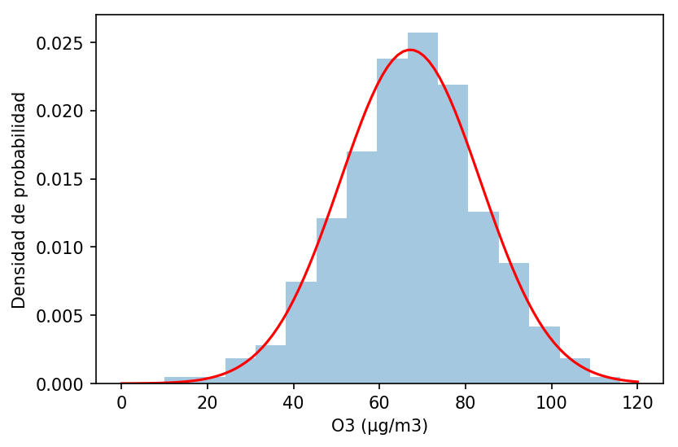

```python
plt.figure(dpi=150)
sns.distplot(df['o3'], bins=15, kde=False, norm_hist=True)
x = np.linspace(0, 120, 100)
rv = norm(loc=mu, scale=s)
plt.plot(x, rv.pdf(x), color='r')
plt.xlabel("O3 (µg/m3)")
plt.ylabel("Densidad de probabilidad");
```

```python
confint_mean_normal(mu, s, df.shape[0], 0.05)
```

|  | 2.5% | 97.5% |
| --- | --- | --- |
| 0 | 67.142271 | 67.17484 |

```python
confint_variance(s, df.shape[0], 0.05)
```

|  | 2.5% | 97.5% |
| --- | --- | --- |
| 0 | 16.294558 | 16.317588 |

### PM<sub>2.5</sub>

```python
mu = df['pm2_5'].mean()
s = df['pm2_5'].std()
print("Cantidad de PM2.5 media de la muestra: %.2f" % mu)
print("Desviación típica de la medida de PM2.5 de la muestra: %.2f" % s)
```

```
Cantidad de PM2.5 media de la muestra: 5.63
Desviación típica de la medida de PM2.5 de la muestra: 2.95
```

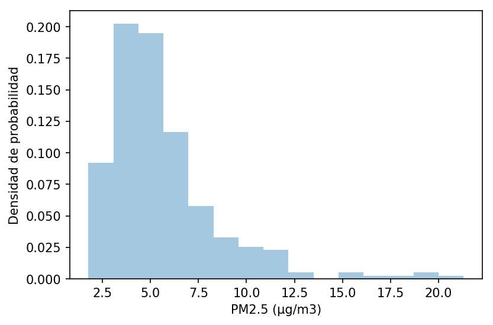

```python
plt.figure(dpi=150)
sns.distplot(df['pm2_5'], bins=15, kde=False, norm_hist=True)
plt.xlabel("PM2.5 (µg/m3)")
plt.ylabel("Densidad de probabilidad");
```

```python
confint_mean_normal(mu, s, df.shape[0], 0.05)
```

|  | 2.5% | 97.5% |
| --- | --- | --- |
| 0 | 5.623628 | 5.629517 |

```python
confint_variance(s, df.shape[0], 0.05)
```

|  | 2.5% | 97.5% |
| --- | --- | --- |
| 0 | 2.945972 | 2.950135 |

# Distribución del porcentaje de ocupación

```python
mu = df['occupation_perc'].mean()
s = df['occupation_perc'].std()
print("Ocupación media de la muestra: %.2f" % mu)
print("Desviación típica de la ocupación de la muestra: %.2f" % s)
```

```
Ocupación media de la muestra: 18.45
Desviación típica de la ocupación de la muestra: 16.10
```

```
Text(0,0.5,'Densidad de probabilidad')
```

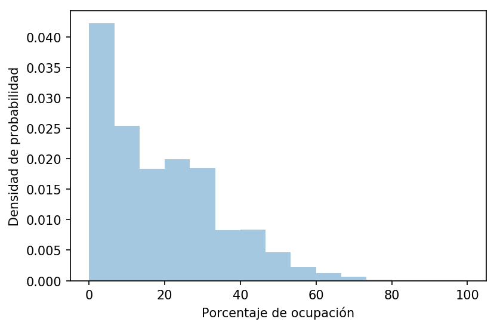

```python
plt.figure(dpi=150)
sns.distplot(df['occupation_perc'], bins=15, kde=False, norm_hist=True)
plt.xlabel("Porcentaje de ocupación")
plt.ylabel("Densidad de probabilidad")
```

```python
confint_mean_normal(mu, s, df.shape[0], 0.05)
```

|  | 2.5% | 97.5% |
| --- | --- | --- |
| 0 | 18.437076 | 18.469228 |

```python
confint_variance(s, df.shape[0], 0.05)
```

|  | 2.5% | 97.5% |
| --- | --- | --- |
| 0 | 16.086027 | 16.108762 |

# Correlaciones entre las covariantes y el target

Correlación de Pearson. Se dan dos p-valor. El primero es la probabilidad de que otra muestra dé el mismo coeficiente que el calculado, estando incorrelada. El otro p-valor calculado se utiliza para establecer si el coeficiente es significativamente distinto de cero. Este segundo test es una comprobación del primer valor (**porque la documentación dice que es aproximado y no siempre es fiable**), y se hace mediante un t-test.

El citado t-test hace lo siguiente:

1. Calcula el coeficiente de correlación de Pearson de la muestra ($r$)
2. Calcula el estadístico $t$, que se distribuye según una t de Student con $N-2$ grados de libertad:

$t = \dfrac{r}{\sqrt{1-r^2}}\cdot \sqrt{N-2} \sim t_{N-2}$

El p-valor se calcula con dos colas, como la probabilidad de obtener un valor más extremo que el estadístico calculado. Como nuestro dataset tiene muchas muestras, y $\sqrt{N-2} \gg \frac{r}{\sqrt{1-r^2}}$, los resultados casi siempre son significativos, porque el estadístico queda siempre muy a la derecha (o a la izquierda) del valor crítico.

```python
from scipy.stats import pearsonr
```

```python
def t_test_pearson(r, N):
    from scipy.stats import t
    import numpy as np
    st = r*np.sqrt(N-2)/np.sqrt(1-r**2)
    p = 2*t(N-2).cdf(-abs(st))
    return (st,p)
```

```python
t_test_pearson(0.006, df.shape[0])
```

```
(11.775602911684038, 5.220899658917703e-32)
```

```python
t(df.shape[0]).ppf(0.025)
```

```
-1.9599646004483897
```

```python
(r, p) = pearsonr(df.occupation_perc, df.tmax)
print("Correlación entre 'occupation_perc' y 'tmax' = %.3f (p= %.3e)" %(r,p))
print("¿Significativamente distinto de cero? Sí: p = %.3e" % t_test_pearson(r, df.shape[0])[1])
```

```
Correlación entre 'occupation_perc' y 'tmax' = 0.005 (p= 2.793e-25)
¿Significativamente distinto de cero? Sí: p = 2.793e-25
```

```python
(r, p) = pearsonr(df.occupation_perc, df.tmin)
print("Correlación entre 'occupation_perc' y 'tmin' = %.3f (p = %.2e)" % (r,p))
print("¿Significativamente distinto de cero? Sí: p = %.3e" % t_test_pearson(r, df.shape[0])[1])
```

```
Correlación entre 'occupation_perc' y 'tmin' = 0.006 (p = 2.34e-29)
¿Significativamente distinto de cero? Sí: p = 2.343e-29
```

```python
(r, p) = pearsonr(df.occupation_perc, df.prcp)
print("Correlación entre 'occupation_perc' y 'prcp' = %.3f (p = %.2e)" % (r,p))
print("¿Significativamente distinto de cero? Sí: p = %.3e" % t_test_pearson(r, df.shape[0])[1])
```

```
Correlación entre 'occupation_perc' y 'prcp' = -0.006 (p = 5.23e-35)
¿Significativamente distinto de cero? Sí: p = 5.227e-35
```

```python
(r, p) = pearsonr(df.occupation_perc, df.road_temp)
print("Correlación entre 'occupation_perc' y 'road_temp' = %.3f (p = %.2e)" % (r,p))
print("¿Significativamente distinto de cero? Sí: p = %.3e" % t_test_pearson(r, df.shape[0])[1])
```

```
Correlación entre 'occupation_perc' y 'road_temp' = 0.027 (p = 0.00e+00)
¿Significativamente distinto de cero? Sí: p = 0.000e+00
```

```python
(r, p) = pearsonr(df.occupation_perc, df.air_temp)
print("Correlación entre 'occupation_perc' y 'air_temp' = %.3f (p = %.2e)" % (r,p))
print("¿Significativamente distinto de cero? Sí: p = %.3e" % t_test_pearson(r, df.shape[0])[1])
```

```
Correlación entre 'occupation_perc' y 'air_temp' = 0.012 (p = 1.76e-120)
¿Significativamente distinto de cero? Sí: p = 1.764e-120
```

```python
(r, p) = pearsonr(df.occupation_perc, df.no2)
print("Correlación entre 'occupation_perc' y 'no2' = %.3f (p = %.2e)" % (r,p))
print("¿Significativamente distinto de cero? Sí: p = %.3e" % t_test_pearson(r, df.shape[0])[1])
```

```
Correlación entre 'occupation_perc' y 'no2' = -0.004 (p = 6.30e-12)
¿Significativamente distinto de cero? Sí: p = 6.305e-12
```

```python
(r, p) = pearsonr(df.occupation_perc, df.co)
print("Correlación entre 'occupation_perc' y 'co' = %.3f (p = %.2e)" % (r,p))
print("¿Significativamente distinto de cero? Sí: p = %.3e" % t_test_pearson(r, df.shape[0])[1])
```

```
Correlación entre 'occupation_perc' y 'co' = 0.003 (p = 4.13e-10)
¿Significativamente distinto de cero? Sí: p = 4.129e-10
```

```python
(r, p) = pearsonr(df.occupation_perc, df.o3)
print("Correlación entre 'occupation_perc' y 'o3' = %.3f (p = %.2e)" % (r,p))
print("¿Significativamente distinto de cero? Sí: p = %.3e" % t_test_pearson(r, df.shape[0])[1])
```

```
Correlación entre 'occupation_perc' y 'o3' = 0.010 (p = 5.23e-93)
¿Significativamente distinto de cero? Sí: p = 5.233e-93
```

```python
(r, p) = pearsonr(df.occupation_perc, df.pm2_5)
print("Correlación entre 'occupation_perc' y 'pm2_5' = %.3f (p = %.2e)" % (r,p))
print("¿Significativamente distinto de cero? Sí: p = %.3e" % t_test_pearson(r, df.shape[0])[1])
```

```
Correlación entre 'occupation_perc' y 'pm2_5' = -0.001 (p = 1.40e-02)
¿Significativamente distinto de cero? Sí: p = 1.403e-02
```

```python
(r, p) = pearsonr(df.occupation_perc, df.latitude)
print("Correlación entre 'occupation_perc' y 'latitude' = %.3f (p = %.2e)" % (r,p))
print("¿Significativamente distinto de cero? Sí: p = %.3e" % t_test_pearson(r, df.shape[0])[1])
```

```
Correlación entre 'occupation_perc' y 'latitude' = 0.094 (p = 0.00e+00)
¿Significativamente distinto de cero? Sí: p = 0.000e+00
```

```python
(r, p) = pearsonr(df.occupation_perc, df.longitude)
print("Correlación entre 'occupation_perc' y 'longitude' = %.3f (p = %.2e)" % (r,p))
print("¿Significativamente distinto de cero? Sí: p = %.3e" % t_test_pearson(r, df.shape[0])[1])
```

```
Correlación entre 'occupation_perc' y 'longitude' = -0.126 (p = 0.00e+00)
¿Significativamente distinto de cero? Sí: p = 0.000e+00
```

```python
(r, p) = pearsonr(df.occupation_perc, df.timestamp.dt.hour)
print("Correlación entre 'occupation_perc' y la hora  = %.3f (p = %.2e)" % (r,p))
print("¿Significativamente distinto de cero? Sí: p = %.3e" % t_test_pearson(r, df.shape[0])[1])
```

```
Correlación entre 'occupation_perc' y la hora  = -0.092 (p = 0.00e+00)
¿Significativamente distinto de cero? Sí: p = 0.000e+00
```

```python
(r, p) = pearsonr(df.occupation_perc, df.timestamp.dt.day)
print("Correlación entre 'occupation_perc' y el día de la semana  = %.3f (p = %.2e)" % (r,p))
print("¿Significativamente distinto de cero? Sí: p = %.3e" % t_test_pearson(r, df.shape[0])[1])
```

[output not shown]

```python
(r, p) = pearsonr(df.occupation_perc, df.timestamp.dt.month)
print("Correlación entre 'occupation_perc' y el mes  = %.3f (p = %.2e)" % (r,p))
print("¿Significativamente distinto de cero? Sí: p = %.3e" % t_test_pearson(r, df.shape[0])[1])
```

```
Correlación entre 'occupation_perc' y el mes  = -0.013 (p = 1.08e-134)
¿Significativamente distinto de cero? Sí: p = 1.076e-134
```

```python
(r, p) = pearsonr(df.occupation_perc, df.day_year)
print("Correlación entre 'occupation_perc' y el día del año  = %.3f (p = %.2e)" % (r,p))
print("¿Significativamente distinto de cero? Sí: p = %.3e" % t_test_pearson(r, df.shape[0])[1])
```

```
Correlación entre 'occupation_perc' y el día del año  = -0.013 (p = 3.91e-137)
¿Significativamente distinto de cero? Sí: p = 3.910e-137
```

# Correlaciones entre las covariantes (entre sí)

A continuación se repite el análisis para estudiar si hay correlaciones entre las covariantes. Este análisis puede llevarnos a descubrir si hay multicolinealidad que pudiera afectar a la parte regresiva de los modelos espacio-temporales.

```python
(r, p) = pearsonr(df.tmin, df.tmax)
print("Correlación entre 'tmin' y 'tmax' = %.3f (p= %.3e)" %(r,p))
print("¿Significativamente distinto de cero? Sí: p = %.3e" % t_test_pearson(r, df.shape[0])[1])
```

```
Correlación entre 'tmin' y 'tmax' = 0.879 (p= 0.000e+00)
¿Significativamente distinto de cero? Sí: p = 0.000e+00
```

```python
(r, p) = pearsonr(df.prcp, df.tmax)
print("Correlación entre 'prcp' y 'tmax' = %.3f (p= %.3e)" %(r,p))
print("¿Significativamente distinto de cero? Sí: p = %.3e" % t_test_pearson(r, df.shape[0])[1])
```

```
Correlación entre 'prcp' y 'tmax' = -0.273 (p= 0.000e+00)
¿Significativamente distinto de cero? Sí: p = 0.000e+00
```

```python
(r, p) = pearsonr(df.road_temp, df.tmax)
print("Correlación entre 'road_temp' y 'tmax' = %.3f (p= %.3e)" %(r,p))
print("¿Significativamente distinto de cero? Sí: p = %.3e" % t_test_pearson(r, df.shape[0])[1])
```

```
Correlación entre 'road_temp' y 'tmax' = 0.873 (p= 0.000e+00)
¿Significativamente distinto de cero? Sí: p = 0.000e+00
```

```python
(r, p) = pearsonr(df.air_temp, df.tmax)
print("Correlación entre 'air_temp' y 'tmax' = %.3f (p= %.3e)" %(r,p))
print("¿Significativamente distinto de cero? Sí: p = %.3e" % t_test_pearson(r, df.shape[0])[1])
```

```
Correlación entre 'air_temp' y 'tmax' = 0.901 (p= 0.000e+00)
¿Significativamente distinto de cero? Sí: p = 0.000e+00
```

```python
(r, p) = pearsonr(df.no2, df.tmax)
print("Correlación entre 'no2' y 'tmax' = %.3f (p= %.3e)" %(r,p))
print("¿Significativamente distinto de cero? Sí: p = %.3e" % t_test_pearson(r, df.shape[0])[1])
```

```
Correlación entre 'no2' y 'tmax' = 0.111 (p= 0.000e+00)
¿Significativamente distinto de cero? Sí: p = 0.000e+00
```

```python
(r, p) = pearsonr(df.co, df.tmax)
print("Correlación entre 'co' y 'tmax' = %.3f (p= %.3e)" %(r,p))
print("¿Significativamente distinto de cero? Sí: p = %.3e" % t_test_pearson(r, df.shape[0])[1])
```

```
Correlación entre 'co' y 'tmax' = -0.164 (p= 0.000e+00)
¿Significativamente distinto de cero? Sí: p = 0.000e+00
```

```python
(r, p) = pearsonr(df.o3, df.tmax)
print("Correlación entre 'o3' y 'tmax' = %.3f (p= %.3e)" %(r,p))
print("¿Significativamente distinto de cero? Sí: p = %.3e" % t_test_pearson(r, df.shape[0])[1])
```

```
Correlación entre 'o3' y 'tmax' = 0.230 (p= 0.000e+00)
¿Significativamente distinto de cero? Sí: p = 0.000e+00
```

```python
(r, p) = pearsonr(df.pm2_5, df.tmax)
print("Correlación entre 'pm2_5' y 'tmax' = %.3f (p= %.3e)" %(r,p))
print("¿Significativamente distinto de cero? Sí: p = %.3e" % t_test_pearson(r, df.shape[0])[1])
```

```
Correlación entre 'pm2_5' y 'tmax' = -0.076 (p= 0.000e+00)
¿Significativamente distinto de cero? Sí: p = 0.000e+00
```

```python
(r, p) = pearsonr(df.prcp, df.tmin)
print("Correlación entre 'prcp' y 'tmin' = %.3f (p= %.3e)" %(r,p))
print("¿Significativamente distinto de cero? Sí: p = %.3e" % t_test_pearson(r, df.shape[0])[1])
```

```
Correlación entre 'prcp' y 'tmin' = -0.106 (p= 0.000e+00)
¿Significativamente distinto de cero? Sí: p = 0.000e+00
```

```python
(r, p) = pearsonr(df.road_temp, df.tmin)
print("Correlación entre 'road_temp' y 'tmin' = %.3f (p= %.3e)" %(r,p))
print("¿Significativamente distinto de cero? Sí: p = %.3e" % t_test_pearson(r, df.shape[0])[1])
```

```
Correlación entre 'road_temp' y 'tmin' = 0.795 (p= 0.000e+00)
¿Significativamente distinto de cero? Sí: p = 0.000e+00
```

```python
(r, p) = pearsonr(df.air_temp, df.tmin)
print("Correlación entre 'air_temp' y 'tmin' = %.3f (p= %.3e)" %(r,p))
print("¿Significativamente distinto de cero? Sí: p = %.3e" % t_test_pearson(r, df.shape[0])[1])
```

```
Correlación entre 'air_temp' y 'tmin' = 0.867 (p= 0.000e+00)
¿Significativamente distinto de cero? Sí: p = 0.000e+00
```

```python
(r, p) = pearsonr(df.no2, df.tmin)
print("Correlación entre 'no2' y 'tmin' = %.3f (p= %.3e)" %(r,p))
print("¿Significativamente distinto de cero? Sí: p = %.3e" % t_test_pearson(r, df.shape[0])[1])
```

```
Correlación entre 'no2' y 'tmin' = -0.086 (p= 0.000e+00)
¿Significativamente distinto de cero? Sí: p = 0.000e+00
```

```python
(r, p) = pearsonr(df.co, df.tmin)
print("Correlación entre 'co' y 'tmin' = %.3f (p= %.3e)" %(r,p))
print("¿Significativamente distinto de cero? Sí: p = %.3e" % t_test_pearson(r, df.shape[0])[1])
```

```
Correlación entre 'co' y 'tmin' = -0.347 (p= 0.000e+00)
¿Significativamente distinto de cero? Sí: p = 0.000e+00
```

```python
(r, p) = pearsonr(df.o3, df.tmin)
print("Correlación entre 'o3' y 'tmin' = %.3f (p= %.3e)" %(r,p))
print("¿Significativamente distinto de cero? Sí: p = %.3e" % t_test_pearson(r, df.shape[0])[1])
```

```
Correlación entre 'o3' y 'tmin' = 0.047 (p= 0.000e+00)
¿Significativamente distinto de cero? Sí: p = 0.000e+00
```

```python
(r, p) = pearsonr(df.pm2_5, df.tmin)
print("Correlación entre 'pm2_5' y 'tmin' = %.3f (p= %.3e)" %(r,p))
print("¿Significativamente distinto de cero? Sí: p = %.3e" % t_test_pearson(r, df.shape[0])[1])
```

```
Correlación entre 'pm2_5' y 'tmin' = -0.319 (p= 0.000e+00)
¿Significativamente distinto de cero? Sí: p = 0.000e+00
```

```python
(r, p) = pearsonr(df.road_temp, df.air_temp)
print("Correlación entre 'road_temp' y 'air_temp' = %.3f (p= %.3e)" %(r,p))
print("¿Significativamente distinto de cero? Sí: p = %.3e" % t_test_pearson(r, df.shape[0])[1])
```

```
Correlación entre 'road_temp' y 'air_temp' = 0.934 (p= 0.000e+00)
¿Significativamente distinto de cero? Sí: p = 0.000e+00
```

```python
(r, p) = pearsonr(df.road_temp, df.prcp)
print("Correlación entre 'road_temp' y 'prcp' = %.3f (p= %.3e)" %(r,p))
print("¿Significativamente distinto de cero? Sí: p = %.3e" % t_test_pearson(r, df.shape[0])[1])
```

```
Correlación entre 'road_temp' y 'prcp' = -0.301 (p= 0.000e+00)
¿Significativamente distinto de cero? Sí: p = 0.000e+00
```

```python
(r, p) = pearsonr(df.air_temp, df.prcp)
print("Correlación entre 'air_temp' y 'prcp' = %.3f (p= %.3e)" %(r,p))
print("¿Significativamente distinto de cero? Sí: p = %.3e" % t_test_pearson(r, df.shape[0])[1])
```

```
Correlación entre 'air_temp' y 'prcp' = -0.257 (p= 0.000e+00)
¿Significativamente distinto de cero? Sí: p = 0.000e+00
```

```python
(r, p) = pearsonr(df.no2, df.prcp)
print("Correlación entre 'no2' y 'prcp' = %.3f (p= %.3e)" %(r,p))
print("¿Significativamente distinto de cero? Sí: p = %.3e" % t_test_pearson(r, df.shape[0])[1])
```

```
Correlación entre 'no2' y 'prcp' = -0.006 (p= 8.825e-30)
¿Significativamente distinto de cero? Sí: p = 8.825e-30
```

```python
(r, p) = pearsonr(df.co, df.prcp)
print("Correlación entre 'co' y 'prcp' = %.3f (p= %.3e)" %(r,p))
print("¿Significativamente distinto de cero? Sí: p = %.3e" % t_test_pearson(r, df.shape[0])[1])
```

```
Correlación entre 'co' y 'prcp' = -0.025 (p= 0.000e+00)
¿Significativamente distinto de cero? Sí: p = 0.000e+00
```

```python
(r, p) = pearsonr(df.o3, df.prcp)
print("Correlación entre 'o3' y 'prcp' = %.3f (p= %.3e)" %(r,p))
print("¿Significativamente distinto de cero? Sí: p = %.3e" % t_test_pearson(r, df.shape[0])[1])
```

```
Correlación entre 'o3' y 'prcp' = -0.082 (p= 0.000e+00)
¿Significativamente distinto de cero? Sí: p = 0.000e+00
```

```python
(r, p) = pearsonr(df.pm2_5, df.prcp)
print("Correlación entre 'pm2_5' y 'prcp' = %.3f (p= %.3e)" %(r,p))
print("¿Significativamente distinto de cero? Sí: p = %.3e" % t_test_pearson(r, df.shape[0])[1])
```

```
Correlación entre 'pm2_5' y 'prcp' = -0.215 (p= 0.000e+00)
¿Significativamente distinto de cero? Sí: p = 0.000e+00
```

```python
(r, p) = pearsonr(df.road_temp, df.air_temp)
print("Correlación entre 'road_temp' y 'air_temp' = %.3f (p= %.3e)" %(r,p))
print("¿Significativamente distinto de cero? Sí: p = %.3e" % t_test_pearson(r, df.shape[0])[1])
```

```
Correlación entre 'road_temp' y 'air_temp' = 0.934 (p= 0.000e+00)
¿Significativamente distinto de cero? Sí: p = 0.000e+00
```

```python
(r, p) = pearsonr(df.road_temp, df.no2)
print("Correlación entre 'road_temp' y 'no2' = %.3f (p= %.3e)" %(r,p))
print("¿Significativamente distinto de cero? Sí: p = %.3e" % t_test_pearson(r, df.shape[0])[1])
```

```
Correlación entre 'road_temp' y 'no2' = -0.012 (p= 4.214e-129)
¿Significativamente distinto de cero? Sí: p = 4.214e-129
```

```python
(r, p) = pearsonr(df.road_temp, df.co)
print("Correlación entre 'road_temp' y 'co' = %.3f (p= %.3e)" %(r,p))
print("¿Significativamente distinto de cero? Sí: p = %.3e" % t_test_pearson(r, df.shape[0])[1])
```

```
Correlación entre 'road_temp' y 'co' = -0.237 (p= 0.000e+00)
¿Significativamente distinto de cero? Sí: p = 0.000e+00
```

```python
(r, p) = pearsonr(df.road_temp, df.o3)
print("Correlación entre 'road_temp' y 'o3' = %.3f (p= %.3e)" %(r,p))
print("¿Significativamente distinto de cero? Sí: p = %.3e" % t_test_pearson(r, df.shape[0])[1])
```

```
Correlación entre 'road_temp' y 'o3' = 0.215 (p= 0.000e+00)
¿Significativamente distinto de cero? Sí: p = 0.000e+00
```

```python
(r, p) = pearsonr(df.road_temp, df.pm2_5)
print("Correlación entre 'road_temp' y 'pm2_5' = %.3f (p= %.3e)" %(r,p))
print("¿Significativamente distinto de cero? Sí: p = %.3e" % t_test_pearson(r, df.shape[0])[1])
```

```
Correlación entre 'road_temp' y 'pm2_5' = -0.142 (p= 0.000e+00)
¿Significativamente distinto de cero? Sí: p = 0.000e+00
```

```python
(r, p) = pearsonr(df.air_temp, df.no2)
print("Correlación entre 'air_temp' y 'no2' = %.3f (p= %.3e)" %(r,p))
print("¿Significativamente distinto de cero? Sí: p = %.3e" % t_test_pearson(r, df.shape[0])[1])
```

```
Correlación entre 'air_temp' y 'no2' = -0.034 (p= 0.000e+00)
¿Significativamente distinto de cero? Sí: p = 0.000e+00
```

```python
(r, p) = pearsonr(df.air_temp, df.co)
print("Correlación entre 'air_temp' y 'co' = %.3f (p= %.3e)" %(r,p))
print("¿Significativamente distinto de cero? Sí: p = %.3e" % t_test_pearson(r, df.shape[0])[1])
```

```
Correlación entre 'air_temp' y 'co' = -0.267 (p= 0.000e+00)
¿Significativamente distinto de cero? Sí: p = 0.000e+00
```

```python
(r, p) = pearsonr(df.air_temp, df.o3)
print("Correlación entre 'air_temp' y 'o3' = %.3f (p= %.3e)" %(r,p))
print("¿Significativamente distinto de cero? Sí: p = %.3e" % t_test_pearson(r, df.shape[0])[1])
```

```
Correlación entre 'air_temp' y 'o3' = 0.149 (p= 0.000e+00)
¿Significativamente distinto de cero? Sí: p = 0.000e+00
```

```python
(r, p) = pearsonr(df.air_temp, df.pm2_5)
print("Correlación entre 'air_temp' y 'pm2_5' = %.3f (p= %.3e)" %(r,p))
print("¿Significativamente distinto de cero? Sí: p = %.3e" % t_test_pearson(r, df.shape[0])[1])
```

```
Correlación entre 'air_temp' y 'pm2_5' = -0.173 (p= 0.000e+00)
¿Significativamente distinto de cero? Sí: p = 0.000e+00
```

```python
(r, p) = pearsonr(df.co, df.no2)
print("Correlación entre 'co' y 'no2' = %.3f (p= %.3e)" %(r,p))
print("¿Significativamente distinto de cero? Sí: p = %.3e" % t_test_pearson(r, df.shape[0])[1])
```

```
Correlación entre 'co' y 'no2' = 0.525 (p= 0.000e+00)
¿Significativamente distinto de cero? Sí: p = 0.000e+00
```

```python
(r, p) = pearsonr(df.no2, df.o3)
print("Correlación entre 'no2' y 'o3' = %.3f (p= %.3e)" %(r,p))
print("¿Significativamente distinto de cero? Sí: p = %.3e" % t_test_pearson(r, df.shape[0])[1])
```

```
Correlación entre 'no2' y 'o3' = 0.202 (p= 0.000e+00)
¿Significativamente distinto de cero? Sí: p = 0.000e+00
```

```python
(r, p) = pearsonr(df.no2, df.pm2_5)
print("Correlación entre 'no2' y 'pm2_5' = %.3f (p= %.3e)" %(r,p))
print("¿Significativamente distinto de cero? Sí: p = %.3e" % t_test_pearson(r, df.shape[0])[1])
```

```
Correlación entre 'no2' y 'pm2_5' = 0.487 (p= 0.000e+00)
¿Significativamente distinto de cero? Sí: p = 0.000e+00
```

```python
(r, p) = pearsonr(df.co, df.o3)
print("Correlación entre 'co' y 'o3' = %.3f (p= %.3e)" %(r,p))
print("¿Significativamente distinto de cero? Sí: p = %.3e" % t_test_pearson(r, df.shape[0])[1])
```

```
Correlación entre 'co' y 'o3' = 0.046 (p= 0.000e+00)
¿Significativamente distinto de cero? Sí: p = 0.000e+00
```

```python
(r, p) = pearsonr(df.co, df.pm2_5)
print("Correlación entre 'co' y 'pm2_5' = %.3f (p= %.3e)" %(r,p))
print("¿Significativamente distinto de cero? Sí: p = %.3e" % t_test_pearson(r, df.shape[0])[1])
```

```
Correlación entre 'co' y 'pm2_5' = 0.671 (p= 0.000e+00)
¿Significativamente distinto de cero? Sí: p = 0.000e+00
```

```python
(r, p) = pearsonr(df.o3, df.pm2_5)
print("Correlación entre 'o3' y 'pm2_5' = %.3f (p= %.3e)" %(r,p))
print("¿Significativamente distinto de cero? Sí: p = %.3e" % t_test_pearson(r, df.shape[0])[1])
```

```
Correlación entre 'o3' y 'pm2_5' = 0.018 (p= 8.154e-268)
¿Significativamente distinto de cero? Sí: p = 8.154e-268
```

```python
df.columns
```

```
Index(['element_key', 'latitude', 'longitude', 'timestamp',
       'paid_parking_area', 'day_year', 'occupation_perc', 'prcp', 'tmax',
       'tmin', 'air_temp', 'road_temp', 'poi', 'baseball', 'tennis', 'basket',
       'soccer', 'event', 'no2', 'co', 'pm2_5', 'o3'],
      dtype='object')
```

```python
num_columns = ['occupation_perc', 'prcp', 'tmax', 'tmin', 'air_temp', 'road_temp', 'no2', 'co', 'pm2_5', 'o3']
```

```python
d = df.loc[:, df.columns.isin(num_columns)]
```

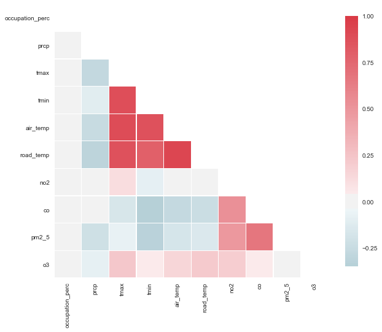

```python
import matplotlib.pyplot as plt

sns.set(style="white")

# Matriz de correlación
corr = d.corr()

# Máscara para el triángulo superior
mask = np.zeros_like(corr, dtype=np.bool)
mask[np.triu_indices_from(mask)] = True

f, ax = plt.subplots(figsize=(10, 15))
cmap = sns.diverging_palette(220, 10, as_cmap=True)  # colormap
sns.heatmap(corr, mask=mask, cmap=cmap, vmax=1, center=0,
            square=True, linewidths=.3, cbar_kws={"shrink": .5});
```

```python
def plot_cdf(num_bins, data, label):
    counts, bin_edges = np.histogram (data, bins=num_bins, normed=True)
    cdf = np.cumsum (counts)
    plt.plot (bin_edges[1:], cdf/cdf[-1], label=label)
```

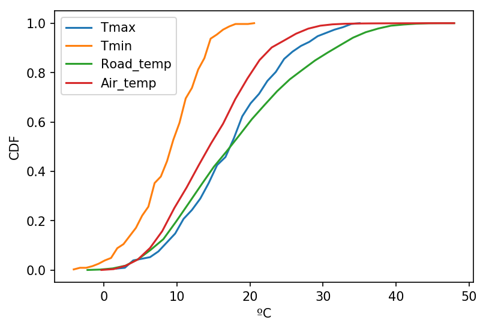

```python
plt.figure(dpi=150)
plot_cdf(30, df.tmax, label='Tmax')
plot_cdf(30, df.tmin, label='Tmin')
plot_cdf(30, df.road_temp, label='Road_temp')
plot_cdf(30, df.air_temp, label='Air_temp')
plt.legend()
plt.xlabel('ºC')
plt.ylabel('CDF');
```

```python
from scipy.stats import ks_2samp

print(ks_2samp(df.tmax, df.tmin))
print(ks_2samp(df.tmax, df.road_temp))
print(ks_2samp(df.tmax, df.air_temp))
print(ks_2samp(df.tmin, df.road_temp))
print(ks_2samp(df.tmin, df.air_temp))
print(ks_2samp(df.road_temp, df.air_temp))
```

```
Ks_2sampResult(statistic=0.5418915045549144, pvalue=0.0)
Ks_2sampResult(statistic=0.11273776736496222, pvalue=0.0)
Ks_2sampResult(statistic=0.1568119649065962, pvalue=0.0)
Ks_2sampResult(statistic=0.5422150011008229, pvalue=0.0)
Ks_2sampResult(statistic=0.43541778306726653, pvalue=0.0)
Ks_2sampResult(statistic=0.21070140074523636, pvalue=0.0)
```

Los valores extremos de p que se están obteniendo se debe a que $N$ es muy grande, y las conclusiones se han obtenido con muchísimos datos, por lo que la mayoría de tests estadísticos van a salir muy significativos.

# Bibliografía

- G. Kanji, *100 statistical tests*, Third Edition, SAGE Publications LTD, 2006
- G. Casella, L. Berger, *Statistical Inference*, Second Edition, Duxbury Advanced Series, 2002.